# Biostat 203B Homework 2 Solutions

Due Feb 12 @ 11:59PM

Analissa Avila

```r
knitr::opts_chunk$set(echo = TRUE, cache = TRUE)
suppressMessages(library(tidyverse))
suppressMessages(library(data.table))
suppressMessages(library(lubridate))
```

```r
mimic_p <- "/usr/203b-data/mimic-iv"
```

Use tidyverse (ggplot2, dplyr) to explore the [MIMIC-IV](https://mimic-iv.mit.edu) data introduced in [homework 1](https://ucla-biostat203b-2021winter.github.io/hw/hw1/hw1.html).

```r
system(str_c("tree -s -L 2 ", shQuote(mimic_p)), intern = TRUE)
```

```
##  [1] "/usr/203b-data/mimic-iv"
##  [2] "├── [         78]  core"
##  [3] "│   ├── [   17224843]  admissions.csv.gz"
##  [4] "│   ├── [    2884996]  patients.csv.gz"
##  [5] "│   └── [   51188147]  transfers.csv.gz"
##  [6] "├── [       4096]  hosp"
##  [7] "│   ├── [     430049]  d_hcpcs.csv.gz"
##  [8] "│   ├── [   26575586]  diagnoses_icd.csv.gz"
##  [9] "│   ├── [     723633]  d_icd_diagnoses.csv.gz"
## [10] "│   ├── [     564422]  d_icd_procedures.csv.gz"
## [11] "│   ├── [      14845]  d_labitems.csv.gz"
## [12] "│   ├── [   12913088]  drgcodes.csv.gz"
## [13] "│   ├── [  518077567]  emar.csv.gz"
## [14] "│   ├── [  479709397]  emar_detail.csv.gz"
## [15] "│   ├── [    1415469]  hcpcsevents.csv.gz"
```

[output cut: 20 more lines]

## Q1. PhysioNet credential

At this moment, you should already get credentialed on the PhysioNet. Please include a screenshot of your `Data Use Agreement for the MIMIC-IV (v0.4)`.

#### Solution:

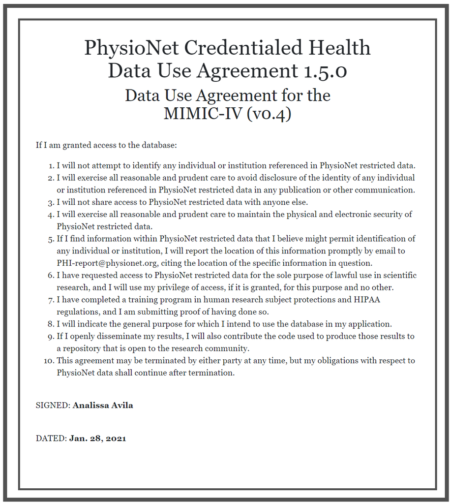

## Q2. `read.csv` (base R) vs `read_csv` (tidyverse) vs `fread` (data.table)

There are quite a few utilities in R for reading data files. Let us test the speed of reading a moderate sized compressed csv file, `admissions.csv.gz`, by three programs: `read.csv` in base R, `read_csv` in tidyverse, and `fread` in the popular data.table package. Is there any speed difference?

In this homework, we stick to the tidyverse.

#### Solution:

Reading `admissions.csv.gz` using `read.csv`

```r
system.time(read.csv(str_c(mimic_p, "/core/admissions.csv.gz")))
```

```
##    user  system elapsed
##  45.776   0.360  46.168
```

Reading `admissions.csv.gz` using `read_csv`

```r
system.time(read_csv(str_c(mimic_p, "/core/admissions.csv.gz")))
```

```
##    user  system elapsed
##   4.161   0.280   5.216
```

Reading `admissions.csv.gz` using `fread`

```r
system.time(fread(str_c(mimic_p, "/core/admissions.csv.gz")))
```

```
##    user  system elapsed
##   2.566   0.286   2.106
```

The `read_csv` function is about 10 times faster than the `read.csv` function. The `fread` function is the fastest, being about twice as fast as the `read_csv` function.

## Q3. ICU stays

`icustays.csv.gz` (https://mimic-iv.mit.edu/docs/datasets/icu/icustays/) contains data about Intensive Care Units (ICU) stays. Summarize following variables using appropriate numerics or graphs:

- how many unique `stay_id`?
- how many unique `subject_id`?
- length of ICU stay
- first ICU unit
- last ICU unit

#### Solution:

Read in `icustays`

```r
icustays_tab <- read_csv(str_c(mimic_p, "/icu/icustays.csv.gz")) %>%
  print(width = Inf)
```

```
## # A tibble: 69,619 x 8
##    subject_id  hadm_id  stay_id first_careunit
##         <dbl>    <dbl>    <dbl> <chr>
##  1   17823467 27561644 35964304 Coronary Care Unit (CCU)
##  2   15772648 26147926 39637383 Trauma SICU (TSICU)
##  3   13713711 25848902 36363748 Trauma SICU (TSICU)
##  4   13173210 22338446 38210858 Coronary Care Unit (CCU)
##  5   10213765 28522861 39765853 Trauma SICU (TSICU)
##  6   17530304 21776160 35848367 Trauma SICU (TSICU)
##  7   10297774 20364526 37788595 Coronary Care Unit (CCU)
##  8   16766597 21185791 39262919 Trauma SICU (TSICU)
##  9   17684317 28656350 36989766 Trauma SICU (TSICU)
## 10   15693895 21203492 34766377 Surgical Intensive Care Unit (SICU)
##    last_careunit                       intime              outtime
##    <chr>                               <dttm>              <dttm>
```

[output cut: 23 more lines]

**How many unique `stay_id`**

```r
icustays_tab %>%
  distinct(stay_id) %>%
  summarise(n_unique_stay_id = n())
```

```
## # A tibble: 1 x 1
##   n_unique_stay_id
##              <int>
## 1            69619
```

**How many unique `subject_id`:** a patient can have more than one ICU stay

```r
icustays_tab %>%
  distinct(subject_id) %>%
  summarise(n_unique_subject_id = n())
```

```
## # A tibble: 1 x 1
##   n_unique_subject_id
##                 <int>
## 1               50048
```

**Distribution of length of ICU stay:** histogram and summary statistics  
The length of ICU stay ranges from 0.03 to 599.25 days. The median length of stay is 2.06 days with 75% of stays lasting 4.2 days or less.

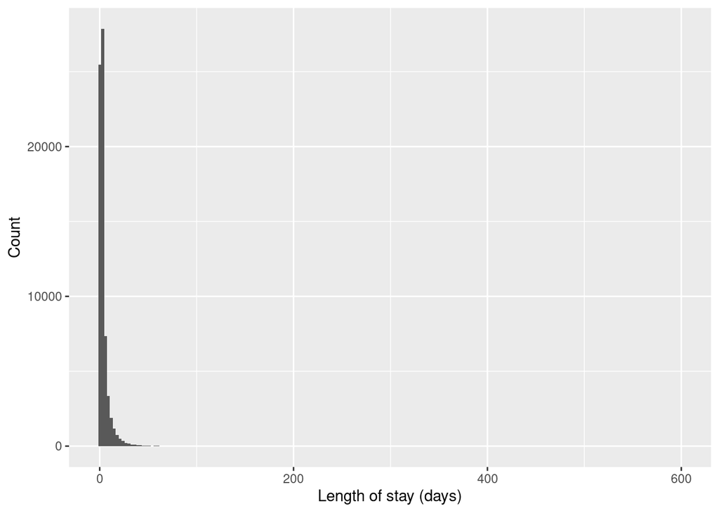

```r
ggplot(data = icustays_tab) +
  geom_histogram(mapping = aes(x = los), bins=200) +
  xlab("Length of stay (days)") +
  ylab("Count")
```

```r
options(pillar.sigfig = 5) #set number of significant figures to include when knit tibble

icustays_tab %>%
  summarise(min = round(min(los), 2),
            mean = round(mean(los), 2),
            sd = round(sd(los), 2),
            Q1 = round(quantile(los, .25), 2),
            median = round(median(los), 2),
            Q3 = round(quantile(los, .75), 2),
            max = round(max(los), 2))
```

```
## # A tibble: 1 x 7
##     min  mean    sd    Q1 median    Q3    max
##   <dbl> <dbl> <dbl> <dbl>  <dbl> <dbl>  <dbl>
## 1  0.03  3.98  6.36 1.130   2.06   4.2 599.25
```

**Distribution of first ICU unit:** bar graph and frequency table  
The medical intensive care unit is the most common first ICU unit

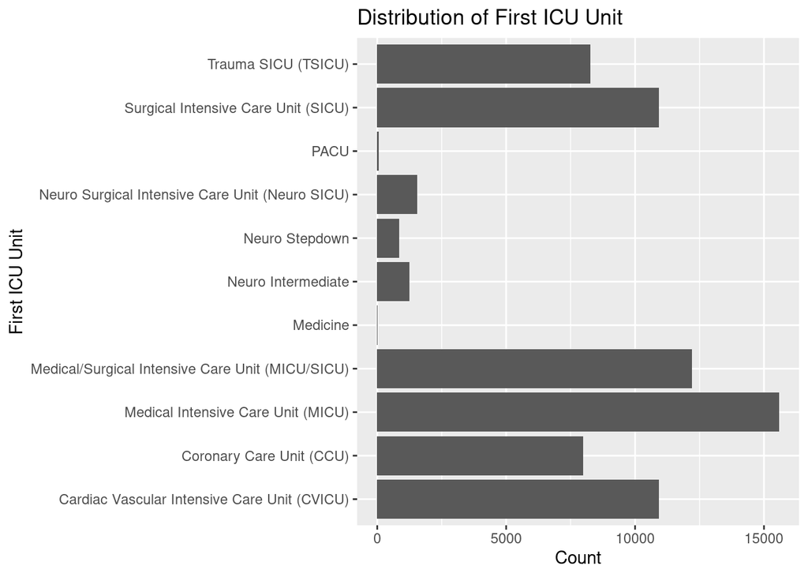

```r
ggplot(data = icustays_tab) +
  geom_bar(mapping = aes(y = first_careunit)) +
  ggtitle("Distribution of First ICU Unit") +
  ylab("First ICU Unit") +
  xlab("Count")
```

```r
options(pillar.sigfig = 5) #set number of significant figures to include when knit tibble

icustays_tab %>%
  group_by(first_careunit) %>%
  summarise(count = n()) %>%
  mutate(percent = round(count/sum(count)*100, 2))
```

```
## # A tibble: 11 x 3
##    first_careunit                                   count percent
##    <chr>                                            <int>   <dbl>
##  1 Cardiac Vascular Intensive Care Unit (CVICU)     10920   15.69
##  2 Coronary Care Unit (CCU)                          7985   11.47
##  3 Medical Intensive Care Unit (MICU)               15587   22.39
##  4 Medical/Surgical Intensive Care Unit (MICU/SICU) 12206   17.53
##  5 Medicine                                            11    0.02
##  6 Neuro Intermediate                                1240    1.78
##  7 Neuro Stepdown                                     861    1.24
##  8 Neuro Surgical Intensive Care Unit (Neuro SICU)   1558    2.24
##  9 PACU                                                68    0.1
## 10 Surgical Intensive Care Unit (SICU)              10915   15.68
## 11 Trauma SICU (TSICU)                               8268   11.88
```

**Distribution of last ICU unit:** bar graph and frequency table  
The medical intensive care unit is the most common last ICU unit

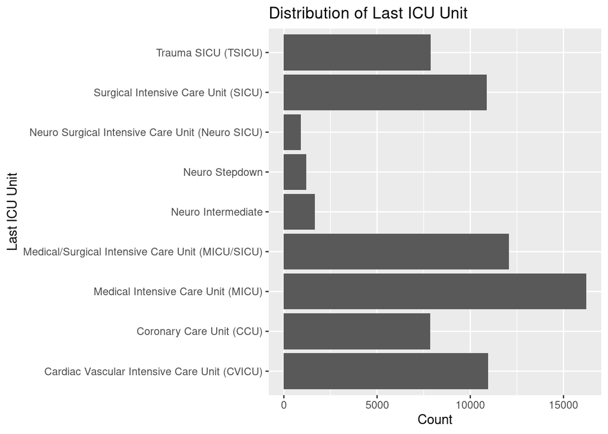

```r
ggplot(data = icustays_tab) +
  geom_bar(mapping = aes(y = last_careunit)) +
  ggtitle("Distribution of Last ICU Unit") +
  ylab("Last ICU Unit") +
  xlab("Count")
```

```r
options(pillar.sigfig = 5) #set number of significant figures to include when knit tibble

icustays_tab %>%
  group_by(last_careunit) %>%
  summarise(count = n()) %>%
  mutate(percent = round(count/sum(count)*100, 2))
```

```
## # A tibble: 9 x 3
##   last_careunit                                    count percent
##   <chr>                                            <int>   <dbl>
## 1 Cardiac Vascular Intensive Care Unit (CVICU)     10946   15.72
## 2 Coronary Care Unit (CCU)                          7859   11.29
## 3 Medical Intensive Care Unit (MICU)               16221   23.3
## 4 Medical/Surgical Intensive Care Unit (MICU/SICU) 12069   17.34
## 5 Neuro Intermediate                                1663    2.39
## 6 Neuro Stepdown                                    1200    1.72
## 7 Neuro Surgical Intensive Care Unit (Neuro SICU)    906    1.3
## 8 Surgical Intensive Care Unit (SICU)              10874   15.62
## 9 Trauma SICU (TSICU)                               7881   11.32
```

## Q4. `admission` data

Information of the patients admitted into hospital is available in `ADMISSION.csv.gz`. See https://mimic-iv.mit.edu/docs/datasets/core/admissions/ for details of each field in this file. Summarize following variables using appropriate graphs. Explain any patterns you observe.

- admission year
- admission month
- admission month day
- admission week day
- admission hour (anything unusual?)
- number of deaths in each year
- admission type
- number of admissions per patient
- admission location
- discharge location
- insurance
- language
- martial status
- ethnicity
- death

Note it is possible that one patient (uniquely identified by the `SUBJECT_ID`) is admitted into hospital multiple times. When summarizing some demographic information, it makes sense to summarize based on unique patients.

#### Solution:

Read in `admissions`

```r
admissions_tab <- read_csv(str_c(mimic_p, "/core/admissions.csv.gz")) %>%
  print(width = Inf)
```

```
## # A tibble: 524,520 x 15
##    subject_id  hadm_id admittime           dischtime
##         <dbl>    <dbl> <dttm>              <dttm>
##  1   12427812 21593330 2184-01-06 11:51:00 2184-01-10 11:45:00
##  2   14029832 22059088 2120-01-18 01:28:00 2120-01-20 16:13:00
##  3   14495017 22484010 2175-01-28 15:41:00 2175-01-29 16:00:00
##  4   13676048 23865469 2193-01-19 05:27:00 2193-01-24 18:59:00
##  5   13831972 27763544 2131-01-27 04:03:00 2131-01-27 05:39:00
##  6   18523038 25414328 2142-08-26 17:14:00 2142-08-27 10:00:00
##  7   16705931 20580522 2174-10-24 11:30:00 2174-10-24 18:45:00
##  8   19963742 24951506 2171-07-04 15:58:00 2171-07-05 13:37:00
##  9   10903424 22568585 2181-01-31 13:09:00 2181-01-31 13:42:00
## 10   15030422 21975876 2149-09-21 23:54:00 2149-09-22 03:59:00
##    deathtime           admission_type         admission_location
##    <dttm>              <chr>                  <chr>
```

[output cut: 35 more lines]

**Summarizing admission year**  
From about the years 2130 to 2190, the number of admissions are fairly constant. There were less admissions both before and after these years.

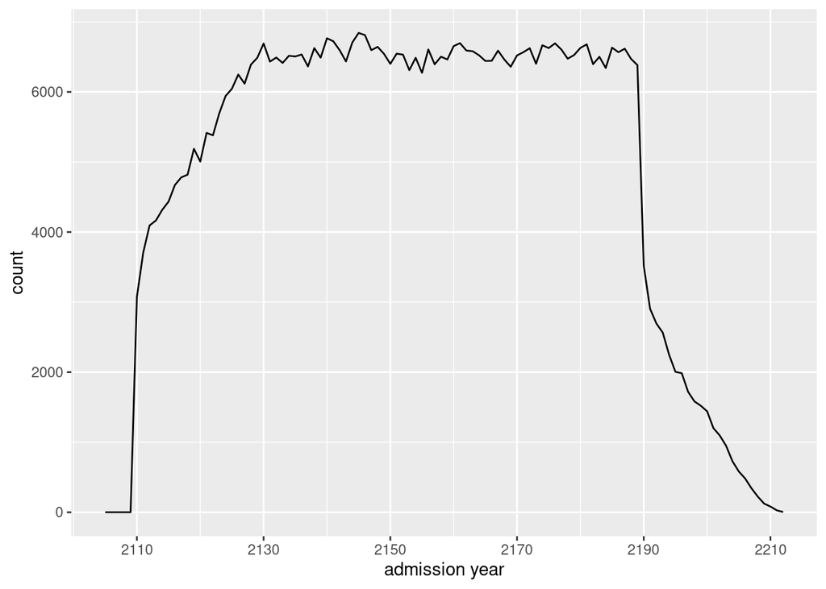

```r
admissions_tab %>%
  count(admityear = year(admittime)) %>%
  ggplot(aes(x = admityear, y = n)) +
  geom_line() +
  xlab("admission year") +
  ylab("count") +
  scale_x_continuous(breaks = seq(2110, 2210, 20))
```

**Summarizing admission month**  
Admissions are fairly evenly distributed across all months. February has the least admissions, which may be due to it being the shortest month.

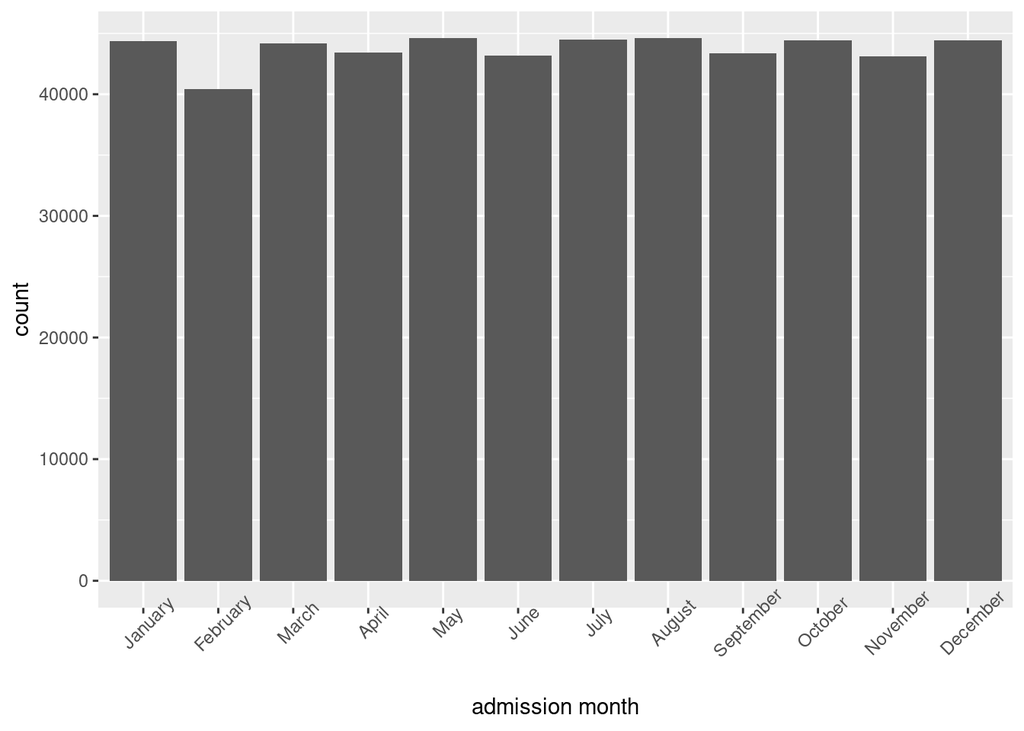

```r
admissions_tab %>%
  mutate(admitmonth = month(admittime, label = TRUE, abbr = FALSE)) %>%
  ggplot(aes(x = admitmonth)) +
  geom_bar() +
  xlab("admission month") +
  ylab("count") +
  theme(axis.text.x = element_text(angle = 45))
```

**Summarizing admission month day**  
Admissions are fairly evenly distributed across the first 28 days of the any month. The 29th, 30th, and 31st days of any month have less admissions. This is possibly explained by the fact that not every month has those days.

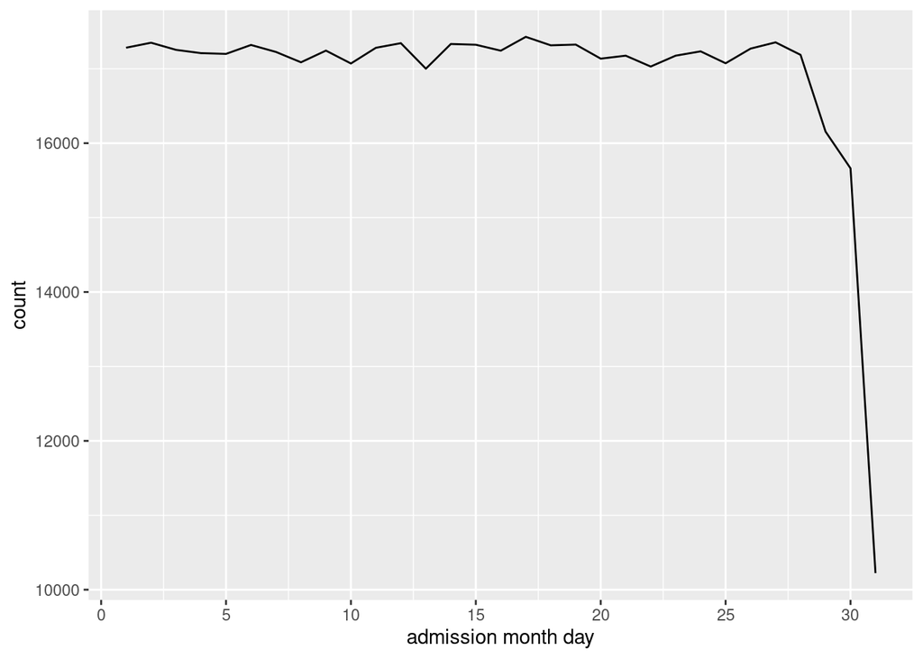

```r
admissions_tab %>%
  count(admitmonth_day = mday(admittime)) %>%
  ggplot(aes(x = admitmonth_day, y = n)) +
  geom_line() +
  xlab("admission month day") +
  ylab("count") +
  scale_x_continuous(breaks = seq(0, 30, 5))
```

**Summarizing admission week day**  
Admissions are fairly evenly distributed across all week days. It seems that there are slightly more admissions on Saturdays.

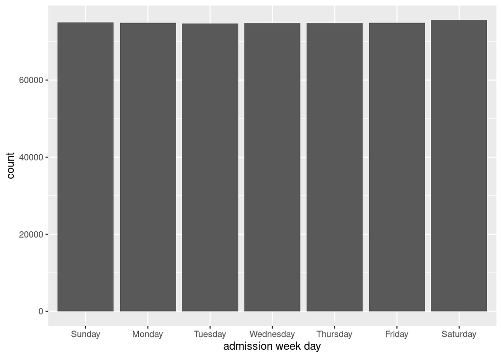

```r
admissions_tab %>%
  mutate(admitweek_day = wday(admittime, label = TRUE, abbr = FALSE)) %>%
  ggplot(aes(x = admitweek_day)) +
  geom_bar() +
  xlab("admission week day") +
  ylab("count")
```

**Summarizing admission hour**  
Admissions are most frequent around midnight. Perhaps there really are more admission at midnight, but it’s also possible that time 0:00 is used when exact admission time is unknown.  
There is a steady decline from midnight until about 6:00am. The admissions then increase from 6:00-7:00am before decreasing again until about 9:00am. From 9:00am to about 6:00pm admissions are steadily increasing. They then began to decrease again from 6:00pm to 11:00pm.

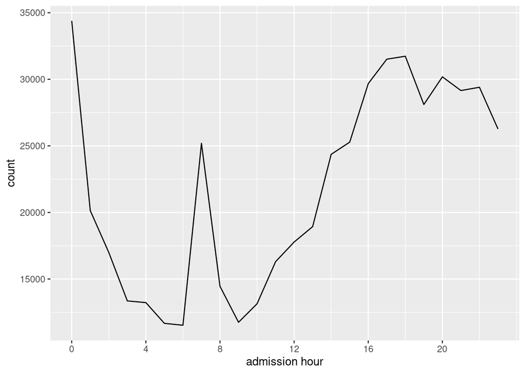

```r
admissions_tab %>%
  count(admithour = hour(admittime)) %>%
  ggplot(aes(x = admithour, y = n)) +
  geom_line() +
  xlab("admission hour") +
  ylab("count") +
  scale_x_continuous(breaks = seq(0, 23, 4))
```

**Summarizing number of deaths in each year**  
The `admissions` data dictionary states that discharge time and death time should be the same, but may differ due to typographical errors. We first look at these two variables to see which we should use to determine death time.

Among patients who died at the hospital, 7 are flagged as having died in two separate hospitalizations (i.e. `hospital_expire_flag` = 1)

```r
admissions_tab %>%
  filter(hospital_expire_flag == 1) %>%
  group_by(subject_id) %>%
  mutate(n_death_records = n_distinct(hadm_id)) %>%
  filter(n_death_records > 1) %>%
  select(subject_id, dischtime, deathtime ,n_death_records)
```

```
## # A tibble: 14 x 4
## # Groups:   subject_id [7]
##    subject_id dischtime           deathtime           n_death_records
##         <dbl> <dttm>              <dttm>                        <int>
##  1   16940596 2118-10-04 00:00:00 2118-10-04 00:00:00               2
##  2   16940596 2118-10-03 20:39:00 2118-10-03 20:39:00               2
##  3   10676055 2150-12-09 16:59:00 NA                                2
##  4   10676055 2150-12-07 16:59:00 NA                                2
##  5   12453379 2135-08-10 13:43:00 2135-08-10 10:08:00               2
##  6   12453379 2135-08-09 10:08:00 2135-08-09 10:08:00               2
##  7   13771243 2178-03-24 08:00:00 2178-03-24 16:25:00               2
##  8   13771243 2178-03-25 16:25:00 2178-03-25 16:25:00               2
##  9   15394378 2155-01-20 22:01:00 2155-01-20 22:01:00               2
## 10   15394378 2155-01-17 22:01:00 2155-01-17 22:01:00               2
## 11   16714180 2114-07-06 07:14:00 2114-07-06 18:47:00               2
## 12   16714180 2114-07-04 18:47:00 2114-07-04 18:47:00               2
## 13   14566049 2135-02-12 11:00:00 2135-02-12 11:00:00               2
## 14   14566049 2135-02-09 08:00:00 2135-02-09 20:30:00               2
```

Among hospitalizations records in which the patient died, none are missing the discharge time but 13 (from 12 unique patients) are missing the death time.

```r
#missing discharge time
admissions_tab %>%
  filter(hospital_expire_flag == 1 & is.na(dischtime)) %>%
  select(subject_id, dischtime)
```

```
## # A tibble: 0 x 2
## # … with 2 variables: subject_id <dbl>, dischtime <dttm>
```

```r
#missing death time
admissions_tab %>%
  filter(hospital_expire_flag == 1 & is.na(deathtime)) %>%
  select(subject_id, deathtime)
```

```
## # A tibble: 13 x 2
##    subject_id deathtime
##         <dbl> <dttm>
##  1   13594875 NA
##  2   14126394 NA
##  3   11600106 NA
##  4   18463717 NA
##  5   10676055 NA
##  6   10676055 NA
##  7   13556244 NA
##  8   11181752 NA
##  9   11553956 NA
## 10   12588483 NA
## 11   12811067 NA
## 12   10176453 NA
## 13   18751817 NA
```

Discharge time and death time discrepancies:  
In addition to the 13 missing death times, there are 634 discrepant discharge and death times. In all 634 cases, **only the time is discrepant**. The dates are exactly the same.

```r
#number of discrepant cases
admissions_tab %>%
  filter(dischtime != deathtime) %>%
  summarise(n_discrepancies = n())
```

```
## # A tibble: 1 x 1
##   n_discrepancies
##             <int>
## 1             634
```

```r
#number of discrepant cases with different dates
admissions_tab %>%
  filter(date(dischtime) != date(deathtime)) %>%
  summarise(n_discrepant_dates = n())
```

```
## # A tibble: 1 x 1
##   n_discrepant_dates
##                <int>
## 1                  0
```

**Since the dates are the same in both variables and `dischtime` does not have any missing values, we will use `dischtime` to analyze death dates**.

The number of deaths each year mostly increases between 2105 to about 2130. The number of deaths then fluctuates between about 100 and 140 until around 2189 before decreasing again.

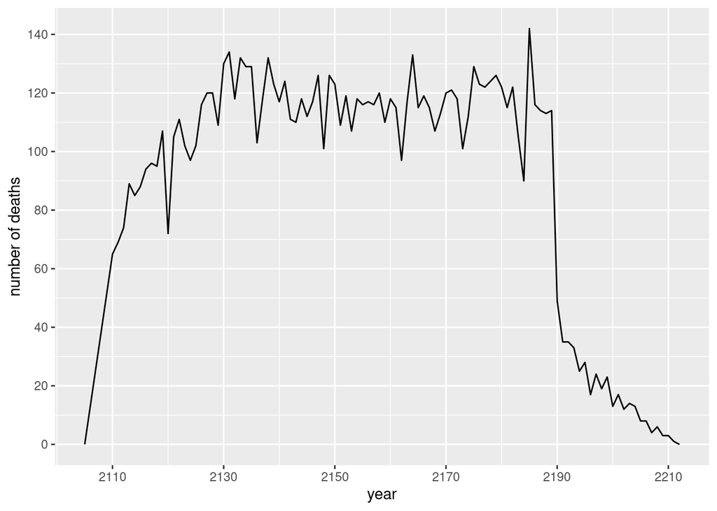

```r
admissions_tab %>%
  mutate(deathyear = year(dischtime)) %>%
  group_by(deathyear) %>%
  summarise(n_deaths = sum(hospital_expire_flag)) %>%
  ggplot(aes(x = deathyear, y = n_deaths)) +
  geom_line() +
  xlab("year") +
  ylab("number of deaths") +
  scale_x_continuous(breaks = seq(2110, 2210, 20)) +
  scale_y_continuous(breaks = seq(0, 150, 20))
```

**Summarizing admission type**  
EW emergency is the most frequent admission type and ambulatory observation is the least frequent.

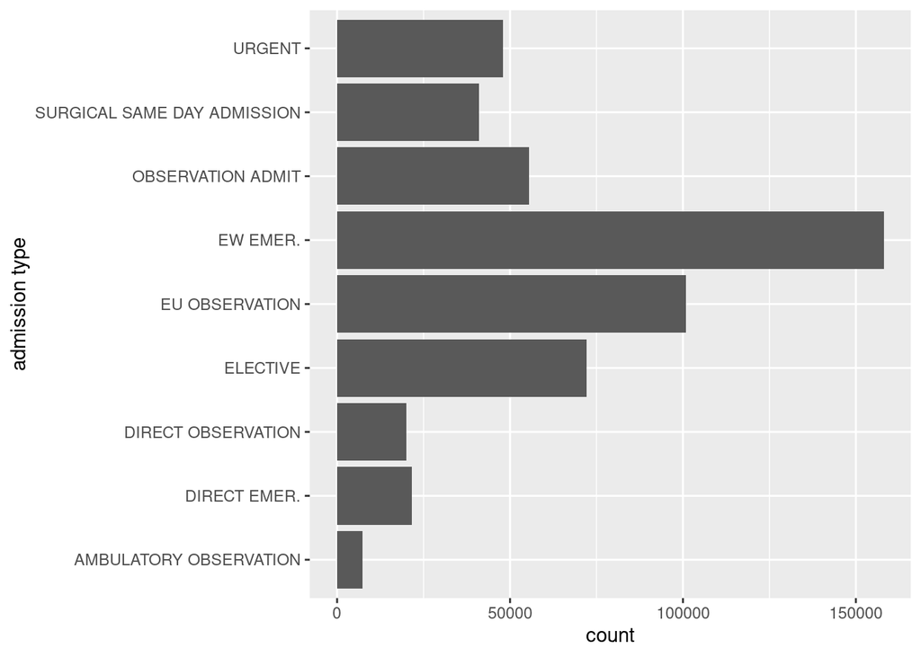

```r
admissions_tab %>%
  ggplot(aes(y = admission_type)) +
  geom_bar() +
  ylab("admission type")
```

**Summarizing number of admissions per patient**  
The number of admissions per patient ranges from 1 to 238. The median number of admissions per patient is 3, with 75% of patients having 7 or less admissions.

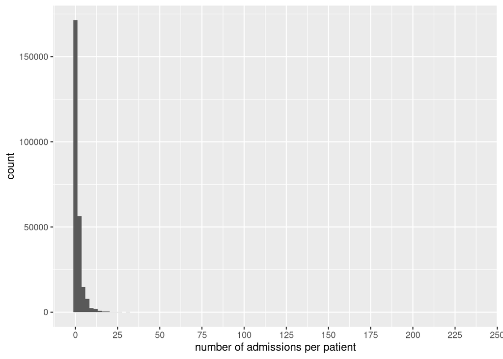

```r
admissions_tab %>%
  group_by(subject_id) %>%
  summarise(n_admissions = n()) %>%
  ggplot(aes(x = n_admissions)) +
  geom_histogram(bins = 100) +
  xlab("number of admissions per patient") +
  scale_x_continuous(breaks = seq(0, 250, 25))
```

```r
admissions_tab %>%
  group_by(subject_id) %>%
  mutate(n_admissions = n()) %>%
  ungroup(subject_id) %>%
  summarise(min = round(min(n_admissions), 2),
            mean = round(mean(n_admissions), 2),
            sd = round(sd(n_admissions), 2),
            Q1 = round(quantile(n_admissions, .25), 2),
            median = round(median(n_admissions), 2),
            Q3 = round(quantile(n_admissions, .75), 2),
            max = round(max(n_admissions), 2))
```

```
## # A tibble: 1 x 7
##     min  mean    sd    Q1 median    Q3   max
##   <dbl> <dbl> <dbl> <dbl>  <dbl> <dbl> <dbl>
## 1     1  6.59 12.47     1      3     7   238
```

**Summarizing admission location**  
The vast majority of admissions were via the emergency room. Admissions via physician referral are the next most common.

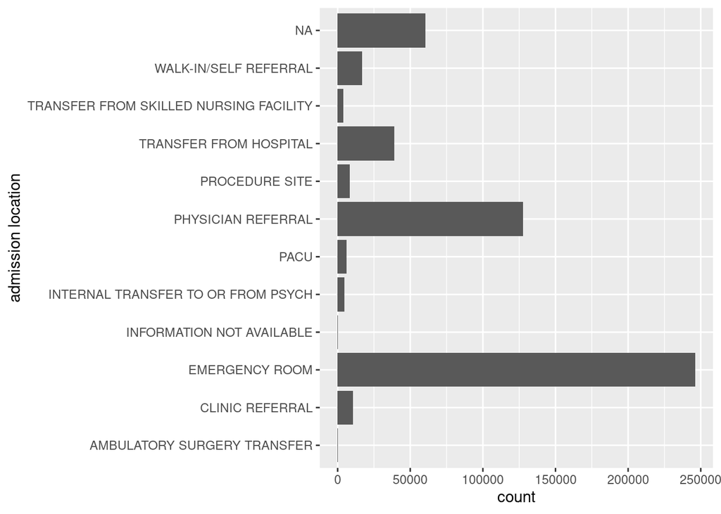

```r
admissions_tab %>%
  ggplot(aes(y = admission_location)) +
  geom_bar() +
  ylab("admission location")
```

**Summarizing discharge location**  
The most frequent discharge location is home. The next most common discharge locations are not available, home health center, and skilled nursing facility.

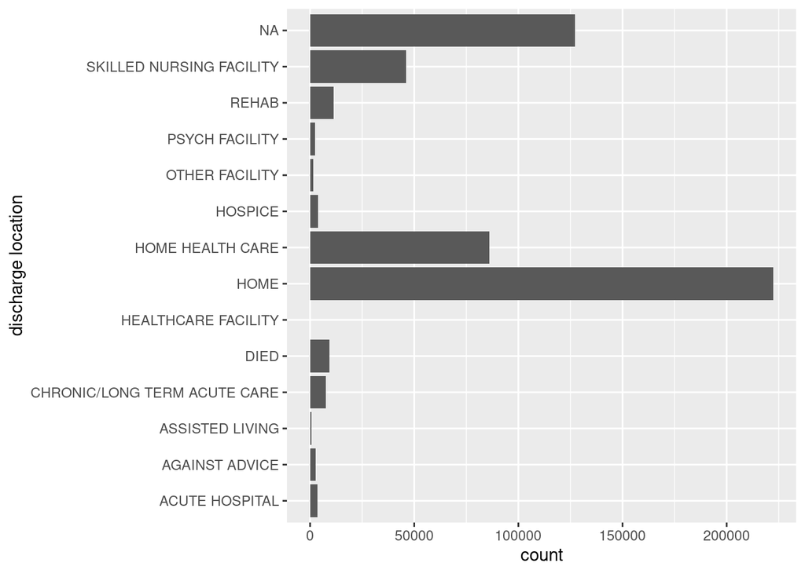

```r
admissions_tab %>%
  ggplot(aes(y = discharge_location)) +
  geom_bar() +
  ylab("discharge location")
```

**Summarizing insurance**  
Since a patient can have more than one type of insurance across admissions, I did not summarize based on unique patients.  
Insurances other than medicare and medicaid are most frequently used. Medicare is more frequently used than medicaid.

```r
# check if patient can have more than one type of insurance
admissions_tab %>%
  group_by(subject_id) %>%
  mutate(n_insurance_pt = n_distinct(insurance)) %>%
  ungroup(subject_id) %>%
  summarise(min = min(n_insurance_pt),
            max = max(n_insurance_pt))
```

```
## # A tibble: 1 x 2
##     min   max
##   <int> <int>
## 1     1     3
```

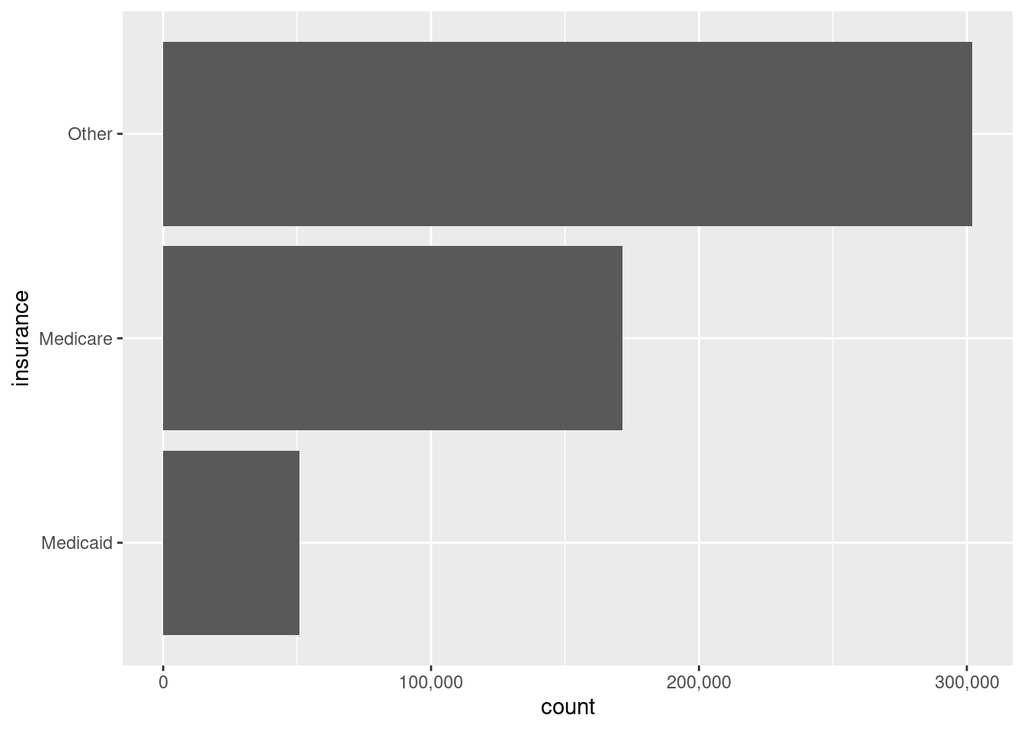

```r
admissions_tab %>%
  ggplot(aes(y = insurance)) +
  geom_bar() +
  ylab("insurance") +
  scale_x_continuous(labels = scales::comma)
```

**Summarizing language**  
I summarized each patients reported language at their **first** admission. There are only two possible language values: English and ? (unknown). English is much more frequent than unknown.

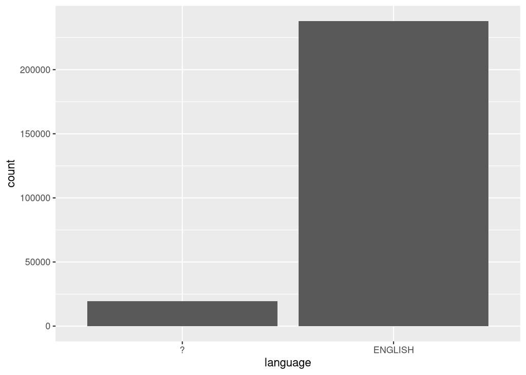

```r
# subset data to only include first admission records for each patient
admissions_tab_first <- admissions_tab %>%
  group_by(subject_id) %>%
  slice(which.min(admittime))

admissions_tab_first %>%
  ggplot(aes(x = language)) +
  geom_bar()
```

**Summarizing marital status**  
I summarized each patients reported marital status at their **first** admission. Married is the most frequent status and divorced is the least frequent.

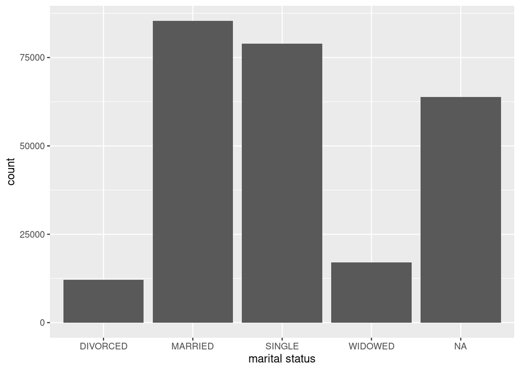

```r
admissions_tab_first %>%
  ggplot(aes(x = marital_status)) +
  geom_bar() +
  xlab("marital status")
```

**Summarizing ethnicity**  
I summarized each patients reported ethnicity at their **first** admission. White is by far the most frequent ethnicity and American Indian/Alaska Native is the least common.

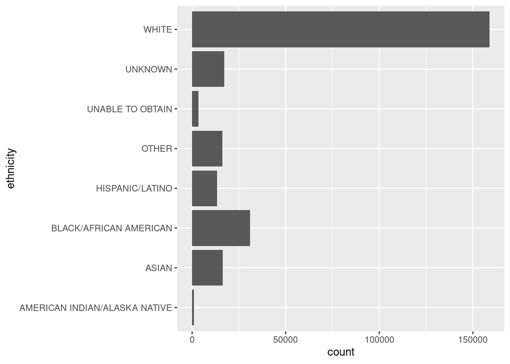

```r
admissions_tab_first %>%
  ggplot(aes(y = ethnicity)) +
  geom_bar()
```

**Summarizing death**  
I summarized death as whether or not each patient had survived up to their **last** discharge time.  
The graph shows that the vast majority of patients did not day during any hospitalization.

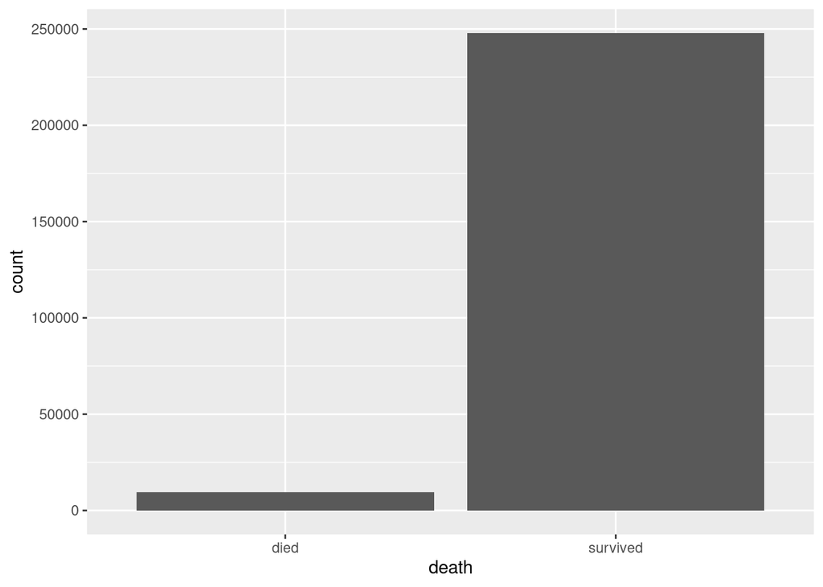

```r
#histogram of death indicator
admissions_tab %>%
  group_by(subject_id) %>%
  mutate(death = sum(hospital_expire_flag)) %>%
  mutate(death = ifelse(death == 0, "survived", "died")) %>%
  slice(which.max(dischtime)) %>%
  ungroup(subject_id) %>%
  ggplot(aes(x = death)) +
  geom_bar()
```

## Q5. `patient` data

Explore `patients.csv.gz` (https://mimic-iv.mit.edu/docs/datasets/core/patients/) and summarize following variables using appropriate numerics and graphs:

- `gender`
- `anchor_age` (explain pattern you see)

#### Soultion:

Read in `patients`

```r
patients_tab <- read_csv(str_c(mimic_p, "/core/patients.csv.gz")) %>%
  print(width = Inf)
```

```
## # A tibble: 383,220 x 6
##    subject_id gender anchor_age anchor_year anchor_year_group dod
##         <dbl> <chr>       <dbl>       <dbl> <chr>             <lgl>
##  1   10002723 F               0        2128 2017 - 2019       NA
##  2   10003939 M               0        2184 2008 - 2010       NA
##  3   10004222 M               0        2161 2014 - 2016       NA
##  4   10005325 F               0        2154 2011 - 2013       NA
##  5   10007338 F               0        2153 2017 - 2019       NA
##  6   10008101 M               0        2142 2008 - 2010       NA
##  7   10009872 F               0        2168 2014 - 2016       NA
##  8   10011333 F               0        2132 2014 - 2016       NA
##  9   10011879 M               0        2158 2014 - 2016       NA
## 10   10012663 F               0        2171 2011 - 2013       NA
## # … with 383,210 more rows
```

**Summarizing gender**  
There are slightly more females than males in the `patient` data set.

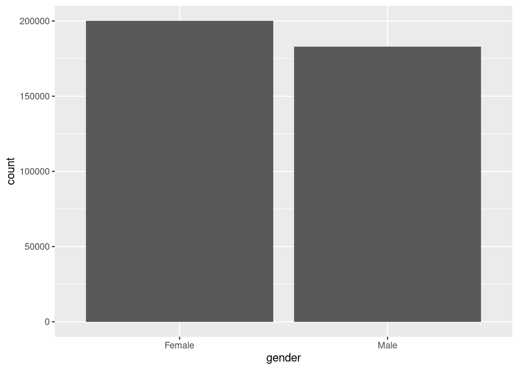

```r
patients_tab %>%
  ggplot(aes(x = gender)) +
  geom_bar() +
  scale_x_discrete(labels = c("Female", "Male"))
```

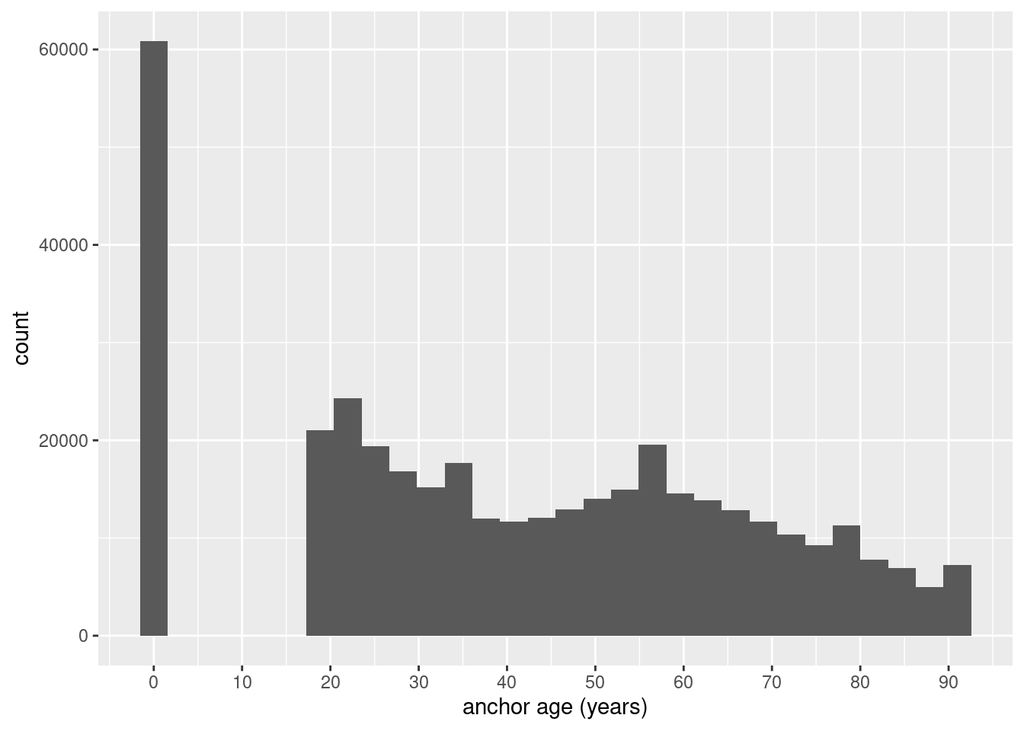

```r
patients_tab %>%
  ggplot(aes(x = anchor_age)) +
  geom_histogram(bins = 30) +
  scale_x_continuous(breaks = seq(0, 100, 10)) +
  xlab("anchor age (years)")
```

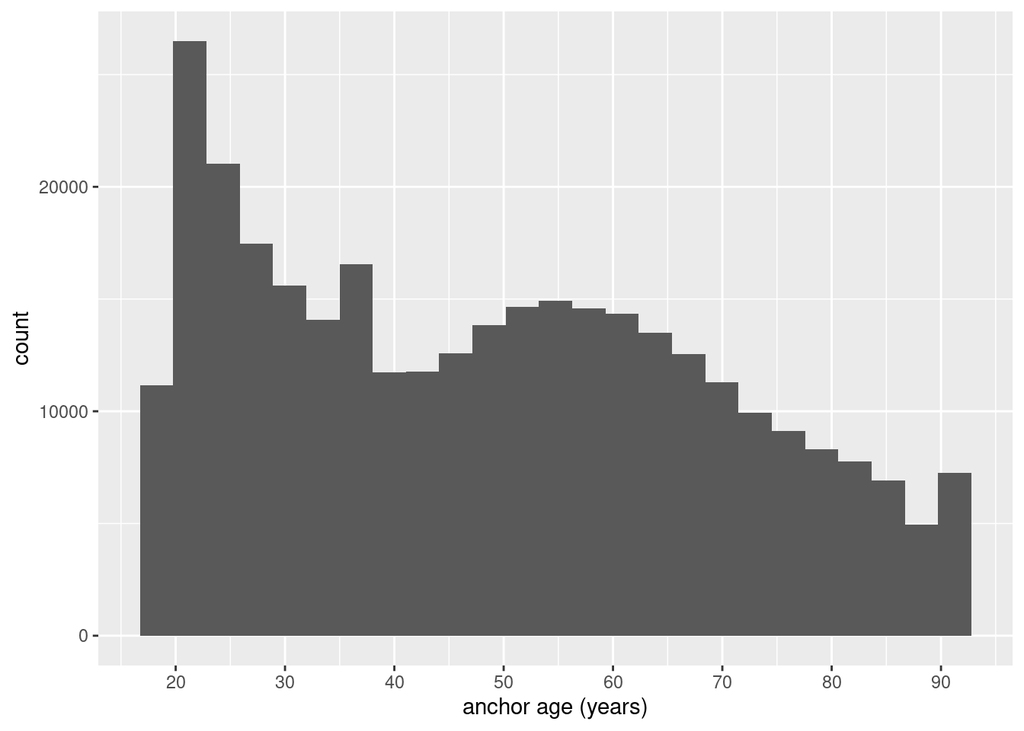

```r
#filter out anchor age of 0
patients_tab %>%
  filter(anchor_age > 0) %>%
  ggplot(aes(x = anchor_age)) +
  geom_histogram(bins = 25) +
  scale_x_continuous(breaks = seq(0, 100, 10)) +
  xlab("anchor age (years)")
```

## Q6. Lab results

`labevents.csv.gz` (https://mimic-iv.mit.edu/docs/datasets/hosp/labevents/) contains all laboratory measurements for patients.

We are interested in the lab measurements of creatinine (50912), potassium (50971), sodium (50983), chloride (50902), bicarbonate (50882), hematocrit (51221), white blood cell count (51301), glucose (50931), magnesium (50960), calcium (50893), and lactate (50813). Find the `itemid`s of these lab measurements from `d_labitems.csv.gz` and retrieve a subset of `labevents.csv.gz` only containing these items.

#### Soultion:

Read in `labevents`

```r
final.lab.file <- TRUE

if(!file.exists("labevents_icustays.csv.gz")){
  system.time(labevents_tab <-
                fread(str_c(mimic_p, "/hosp/labevents.csv.gz"),
                      select = c("subject_id", "hadm_id", "itemid",
                                 "charttime", "valuenum"),
                      nThread = 4))
  labevents_tab %>%
    semi_join(icustays_tab, by = c("subject_id", "hadm_id")) %>%
    fwrite("labevents_icustays.csv.gz", nThread = 4)

  final.lab.file <- FALSE
}
```

Subset to lab measurements of interest.

```r
if(final.lab.file == FALSE){
  # relevant item ids
  itemid_list <- c(50912, 50971, 50983, 50902, 50882, 51221, 51301,
                   50931, 50960, 50893, 50813)

  system.time(labevents_tab <- fread("labevents_icustays.csv.gz"))

  #subset to relevant items only
  labevents_tab %>%
    as_tibble() %>%
    filter(itemid %in% itemid_list) %>%
    mutate(charttime = ymd_hms(charttime)) %>%
    fwrite("labevents_icustays.csv.gz", nThread = 4)

  final.lab.file <- FALSE
}
```

Per question 8, I subset to only include the first lab measurements during the first icu stay for each patient.  
Transform data to wide layout, so that each lab item has its own column.

```r
if(final.lab.file == FALSE){
  #subset to first icu stay for each patient and keep selected columns
  icustays_tab_sub <- icustays_tab %>%
    select(c(subject_id:stay_id, intime)) %>%
    #subset to first ICU stay of each unique patient
    group_by(subject_id) %>%
    slice_min(intime)

  system.time(labevents_tab <- fread("labevents_icustays.csv.gz"))

  #subset to first measurements during ICU stay and keep selected columns
  labevents_tab %>%
    #merge with subset icu data
    left_join(icustays_tab_sub, by = c("subject_id", "hadm_id")) %>%
    #keep only first measurement during icu stay
    filter(charttime >= intime) %>%
    group_by_at(vars(hadm_id, itemid)) %>%
    slice(which.min(charttime)) %>%
    select(-c(charttime, stay_id, intime)) %>%
    #save as csv
    fwrite("labevents_icustays.csv.gz", nThread = 4)

  final.lab.file == TRUE
}

#Read in subset `labevents` data
system.time(labevents_tab <- fread("labevents_icustays.csv.gz"))
```

```
##    user  system elapsed
##   0.361   0.084   0.424
```

```r
#Transform to wide layout
labevents_tab <- labevents_tab %>%
  as_tibble() %>%
  spread(key = itemid, value = valuenum) %>%
  rename(creatinine = "50912",
         potassium = "50971",
         sodium = "50983",
         chloride = "50902",
         bicarbonate = "50882",
         hematocrit = "51221",
         WBC_count = "51301",
         glucose = "50931",
         magnesium = "50960",
         calcium = "50893",
         lactate = "50813") %>%
  print(width = Inf)
```

```
## # A tibble: 49,383 x 13
##    subject_id  hadm_id lactate bicarbonate calcium chloride creatinine glucose
##         <int>    <int>   <dbl>       <dbl>   <dbl>    <dbl>      <dbl>   <dbl>
##  1   14046553 20000094     4            28     9.3       85        3.8     190
##  2   14990224 20000147     1.5          20    NA        105        0.7     157
##  3   17913090 20000351    NA            25     9.2      102        0.8     189
##  4   16058391 20000397    NA            23     9.8      101        1       105
##  5   16788749 20000808     1.4          22     9.5      105        0.6     156
##  6   16003661 20001305     2.3          23    11.4      108        0.8     154
##  7   14577567 20001361     2.7          22     6.3      107        2.5     161
##  8   15975141 20001494    NA            22     8.6      104        0.9     147
##  9   17112572 20001687     2.1          25     8.5      109        1       127
## 10   18921218 20001976     1.7          22     7.7      115        0.9     102
##    magnesium potassium sodium hematocrit WBC_count
##        <dbl>     <dbl>  <dbl>      <dbl>     <dbl>
##  1       2.2       4.6    133       42.1      12.5
##  2       2.9       4.6    134       31.8      10.2
##  3       1.2       3.5    137       39.9       8.6
##  4       2         4.8    136       45.5       6.3
##  5       1.9       4.8    138       37.9       5.4
##  6       2.3       4.3    142       33.4      20.3
##  7       2         5.8    137       33.9      20.8
##  8       1.6       3.5    139       36.9      19.7
##  9       2.4       4.3    145       30.7      10.4
## 10       1.9       4.1    146       38.9       7.1
## # … with 49,373 more rows
```

## Q7. Vitals from chartered events

We are interested in the vitals for ICU patients: heart rate, mean and systolic blood pressure (invasive and noninvasive measurements combined), body temperature, SpO2, and respiratory rate. Find the `itemid`s of these vitals from `d_items.csv.gz` and retrieve a subset of `chartevents.csv.gz` only containing these items.

`chartevents.csv.gz` (https://mimic-iv.mit.edu/docs/datasets/icu/chartevents/) contains all the charted data available for a patient. During their ICU stay, the primary repository of a patient’s information is their electronic chart. The `itemid` variable indicates a single measurement type in the database. The `value` variable is the value measured for `itemid`.

`d_items.csv.gz` (https://mimic-iv.mit.edu/docs/datasets/icu/d_items/) is the dictionary for the `itemid` in `chartevents.csv.gz`.

#### Soultion:

Read in `chartevents`

```r
mimic_derived_p <- "/usr/203b-data/mimic-iv-derived-data"

final.chart.file <- TRUE

if(!file.exists("chartevents_filtered.csv.gz")){
  system.time(chart_tab <- fread(str_c(mimic_derived_p,
                                       "/chartevents_filtered_itemid.csv.gz"),
                                 col.names = c("subject_id",
                                               "hadm_id",
                                               "stay_id",
                                               "charttime",
                                               "itemid",
                                               "valuenum"),
                                 nThread = 4))
  chart_tab %>%
    as_tibble() %>%
    mutate_at(c("subject_id", "hadm_id", "stay_id"), as.numeric) %>%
    mutate(charttime = ymd_hms(charttime)) %>%
    fwrite("chartevents_filtered.csv.gz", nThread = 4)

  final.chart.file <- FALSE
}
```

If I was able to load the original `chartevents` file, I would use the following code to subset to only the relevant `itemid`s. (Relevant labels are per Dr. Zhou)

Read in the chart item dictionary and find relevant `itemid`s

```r
# ditems_tab <- read_csv(str_c(mimic_p, "/icu/d_items.csv.gz")) %>%
#   print(width = Inf)
#
# for(lab in c("Heart Rate", "Blood Pressure mean", "Blood Pressure systolic",
#              "Temperature", "SpO2", "Respiratory Rate")){
#   ditems_tab %>%
#     filter(grepl(lab, label) | grepl(lab, abbreviation)) %>%
#     print(width = Inf)
# }
```

Subset to relevant `itemid`s

```r
# chart_list <- c("Heart Rate", "Arterial Blood Pressure mean",
#                 "Non Invasive Blood Pressure mean",
#                 "Arterial Blood Pressure systolic",
#                 "Non Invasive Blood Pressure systolic",
#                 "Temperature Fahrenheit",
#                 "O2 saturation pulseoxymetry", "Respiratory Rate")
#
# ditems_tab_sub <- ditems_tab %>%
#   filter(label %in% chart_list)
#
#
#   #subset to relevant items only
#   chart_tab %>%
#     filter(itemid %in% ditems_tab_sub$itemid) %>%
#     mutate(charttime = ymd_hms(charttime)) %>%
#     fwrite("labevents_icustays.csv.gz", nThread = 4)
```

Instead, I just need to read in the pre-filtered `chartevents` data set.  
**There is not an `itemid` for SpO2 in this filtered data set. Therefore, SpO2 measurements will not be included in further steps.**

Per question 8, I subset to only include the first vitals measurements during the first icu stay for each patient.  
Transform data to wide layout, so that each chart item has its own column.

```r
if(final.chart.file == FALSE){

  #subset to first icu stay for each patient and keep selected columns
  icustays_tab_sub <- icustays_tab %>%
    select(c(subject_id:stay_id, intime)) %>%
    #subset to first ICU stay of each unique patient
    group_by(subject_id) %>%
    slice_min(intime)

  #subset to first measurements during ICU stay and keep selected columns
  chart_tab %>%
    as_tibble() %>%
    #merge with subset icu data
    left_join(icustays_tab_sub, by = c("subject_id", "hadm_id", "stay_id")) %>%
    #keep only first measurement during icu stay
    filter(charttime >= intime) %>%
    group_by_at(vars(hadm_id, itemid)) %>%
    slice(which.min(charttime)) %>%
    select(-c(charttime, intime)) %>%
    #save as csv
    fwrite("chartevents_filtered.csv.gz", nThread = 4)

  final.chart.file <- TRUE
}

#Read in subset `chartevents` data
system.time(chart_tab <- fread("chartevents_filtered.csv.gz"))
```

```
##    user  system elapsed
##   0.228   0.044   0.265
```

```r
#Transform to wide layout
chart_tab <- chart_tab %>%
  as_tibble() %>%
  spread(key = itemid, value = valuenum) %>%
  rename(heart_rate = "220045",
         ART_BP_mean = "220052",
         NI_BP_mean = "220181",
         ART_BP_systolic = "220050",
         NI_BP_systolic = "220179",
         temperature_fah = "223761",
         respiratory_rate = "220210") %>%
  print(width = Inf)
```

```
## # A tibble: 50,040 x 10
##    subject_id  hadm_id  stay_id heart_rate ART_BP_systolic ART_BP_mean
##         <int>    <int>    <int>      <dbl>           <dbl>       <dbl>
##  1   14046553 20000094 35524507        106              NA          NA
##  2   14990224 20000147 37348463         95             125          91
##  3   17913090 20000351 36749715         86              NA          NA
##  4   16058391 20000397 30495218         80              NA          NA
##  5   16788749 20000808 38439103         85              NA          NA
##  6   16003661 20001305 37696887         76              NA          NA
##  7   14577567 20001361 36493955         78             159         104
##  8   15975141 20001494 39346951         59             122          77
##  9   17112572 20001687 32926753         51             138          93
## 10   18921218 20001976 39738768        102              NA          NA
##    NI_BP_systolic NI_BP_mean respiratory_rate temperature_fah
##             <dbl>      <dbl>            <dbl>           <dbl>
##  1             89         56               30            97.5
##  2            102         84               17            97.6
##  3            149         92               21            98.8
##  4            111         95               16            97.7
##  5            181        122                9            97.2
##  6             89         49               18            98.3
##  7            124         95               16            96.9
##  8            123         79               23            97.7
##  9            139        102               18            98.6
## 10            193        110               27            97
## # … with 50,030 more rows
```

## Q8. Putting things together

Let us create a tibble for all ICU stays, where rows are

- first ICU stay of each unique patient
- adults (age at admission > 18)

and columns contain at least following variables

- all variables in `icustays.csv.gz`
- all variables in `admission.csv.gz`
- all variables in `patients.csv.gz`
- first lab measurements during ICU stay
- first vitals measurement during ICU stay
- an indicator variable whether the patient died within 30 days of hospital admission

#### Solution:

Create tibble as instructed above.  
**Although the bullet above defines adult as ‘age at admission > 18’, I’m using the more standard definition of ‘age at admission >= 18’**  
**As noted in Q7, there will not be a column for SpO2 as there was not a corresponding `itemid` in the filtered `chartevents` data set**

```r
# get death time for each patient that died
death_tab <- admissions_tab %>% group_by(subject_id) %>%
  filter(hospital_expire_flag ==1) %>%
  mutate(died = 1,
         death_time = last(dischtime)) %>%
  slice(which.max(dischtime)) %>%
  select(subject_id, died, death_time)

# create desired data set
icustays_tab_first <- icustays_tab %>%
  #subset to first ICU stay of each unique patient
  group_by(subject_id) %>%
  slice_min(intime) %>%
  #merge with admissions and patients data
  left_join(admissions_tab, by = c("subject_id", "hadm_id")) %>%
  left_join(patients_tab, by = "subject_id") %>%
  #subset to adults (patients age >= 18 at admission)
  mutate(age_at_adm = year(admittime) - anchor_year + anchor_age) %>%
  filter(age_at_adm >= 18) %>%
  #merge with first lab measurements data
  left_join(labevents_tab, by = c("subject_id", "hadm_id")) %>%
  #merge with first vitals measurements data
  left_join(chart_tab, by = c("subject_id", "hadm_id", "stay_id")) %>%
  #merge with death data
  left_join(death_tab, by = "subject_id") %>%
  mutate(died = ifelse(is.na(died), 0, died),
         #time from admission to death
         admit_to_death = difftime(date(death_time), date(admittime),
                                  units = "days"),
         #indicator: died within 30 days of admission
         died_in_30days = ifelse(admit_to_death > 30 |
                                   is.na(admit_to_death), 0, 1)) %>%
  print(width = Inf)
```

```
## # A tibble: 50,048 x 49
## # Groups:   subject_id [50,048]
##    subject_id  hadm_id  stay_id first_careunit
##         <dbl>    <dbl>    <dbl> <chr>
##  1   10000032 29079034 37529680 Medical Intensive Care Unit (MICU)
##  2   10000980 26913865 36742749 Medical Intensive Care Unit (MICU)
##  3   10001217 24597018 30327812 Surgical Intensive Care Unit (SICU)
##  4   10001725 25563031 37542711 Medical/Surgical Intensive Care Unit (MICU/SICU)
##  5   10001884 26184834 31832304 Medical Intensive Care Unit (MICU)
##  6   10002013 23581541 37106138 Cardiac Vascular Intensive Care Unit (CVICU)
##  7   10002155 23822395 34599502 Coronary Care Unit (CCU)
##  8   10002223 22494570 39908879 Trauma SICU (TSICU)
##  9   10002428 28662225 31956612 Medical Intensive Care Unit (MICU)
## 10   10002443 21329021 35217462 Coronary Care Unit (CCU)
##    last_careunit                                    intime
```

[output cut: 120 more lines]